# EDA

```python
import datetime
import os
import warnings
from typing import List

import matplotlib.dates as mdates
import matplotlib.pyplot as plt
import pandas as pd
import seaborn as sns

from statsmodels.tsa.seasonal import seasonal_decompose

warnings.filterwarnings("ignore")
```

## 1 Data config

```python
DATA_DIR = "./data/"
```

```python
TFL_CYCLE_HIRES_DATA_FILENAME = "tfl-daily-cycle-hires.xlsx"
ELECTRICAL_POWER_DATA_FILENAME = "electrical_power_data.csv"
BANK_HOLYDAYS_FILENAME = "ukbankholidays.csv"
```

```python
tfl_cycle_hires_path = os.path.join(DATA_DIR, TFL_CYCLE_HIRES_DATA_FILENAME)
electrical_power_path = os.path.join(DATA_DIR, ELECTRICAL_POWER_DATA_FILENAME)
bank_holidays_path = os.path.join(DATA_DIR, BANK_HOLYDAYS_FILENAME)
```

```python
pd.read_excel(tfl_cycle_hires_path)
```

|  | Name | Number of Bicycle Hires in the Santander Hire Scheme |
| --- | --- | --- |
| 0 | ShortName | Number of Bicycle Hires |
| 1 | NaN | NaN |
| 2 | NaN | NaN |
| 3 | NaN | NaN |
| 4 | Theme | Transport |
| 5 | Sub-theme | Cycling |
| 6 | NaN | NaN |
| 7 | Title | Number of Bicycle Hires |
| 8 | Description | Total number of hires of the Santander Cycle H... |
| 9 | Subject | Cycling |
| 10 | Subject.keyword | cycle hire |
| 11 | Publisher | GLA |
| 12 | Date.available | 30-July-10 to 28-Feb-21 |
| 13 | Creator | Transport for London (TFL) |
| 14 | Date.created | Mar 21 |
| 15 | Coverage.spatial | London |
| 16 | Coverage.temporal | Daily, monthly and annually |
| 17 | Type | Administrative |
| 18 | Language | English |
| 19 | Rights | Transport for London (TFL) |
| 20 | More info | NaN |
| 21 | Download from | NaN |
| 22 | Measure | Numbers |
| 23 | Warnings/Notes | Please note that from 01 August 2017 due to de... |
| 24 | NaN | NaN |
| 25 | NaN | NaN |
| 26 | NaN | NaN |
| 27 | NaN | NaN |
| 28 | Next release | Apr 21 |

```python
pd.read_excel(tfl_cycle_hires_path,
              sheet_name="Data").head()
```

|  | Day | Number of Bicycle Hires | Unnamed: 2 | Month | Number of Bicycle Hires.1 | Unnamed: 5 | Year | Number of Bicycle Hires.2 | Unnamed: 8 | Month.1 | Average Hire Time (mins) |
| --- | --- | --- | --- | --- | --- | --- | --- | --- | --- | --- | --- |
| 0 | 2010-07-30 | 6897 | NaN | 2010-07-01 | 12461.0 | NaN | 2010 | 2180813 | NaN | 2010-07-01 | 17.232566 |
| 1 | 2010-07-31 | 5564 | NaN | 2010-08-01 | 341203.0 | NaN | 2011 | 7142449 | NaN | 2010-08-01 | 16.551880 |
| 2 | 2010-08-01 | 4303 | NaN | 2010-09-01 | 540859.0 | NaN | 2012 | 9519283 | NaN | 2010-09-01 | 15.219079 |
| 3 | 2010-08-02 | 6642 | NaN | 2010-10-01 | 544412.0 | NaN | 2013 | 8045459 | NaN | 2010-10-01 | 15.204481 |
| 4 | 2010-08-03 | 7966 | NaN | 2010-11-01 | 456304.0 | NaN | 2014 | 10023897 | NaN | 2010-11-01 | 13.776083 |

```python
pd.read_csv(electrical_power_path).head()
```

|  | SD | Gas | Coal | Nuclear | Hydro | Net Pumped | Wind | OCGT | Oil | Biomass | French Int | Dutch Int | NI Int | Eire Int | Nemo Int | Net Supply |
| --- | --- | --- | --- | --- | --- | --- | --- | --- | --- | --- | --- | --- | --- | --- | --- | --- |
| 0 | 2010-01-01 | 418,674 | 232,291 | 191,982 | 4,641 | -3,854 | 7,020 | 451 | 0 | 0 | 45,222 | 0 | -8,521 | 0 | 0 | 887,904 |
| 1 | 2010-01-02 | 456,961 | 274,253 | 191,019 | 4,826 | -2,349 | 10,138 | 0 | 0 | 0 | 6,373 | 0 | -7,737 | 0 | 0 | 933,483 |
| 2 | 2010-01-03 | 464,772 | 278,136 | 190,175 | 4,123 | -3,897 | 4,171 | 0 | 0 | 0 | 18,786 | 0 | -6,051 | 0 | 0 | 950,214 |
| 3 | 2010-01-04 | 482,219 | 474,204 | 191,406 | 4,703 | -3,632 | 5,973 | 240 | 0 | 0 | -31,833 | 0 | -7,576 | 0 | 0 | 1,115,702 |
| 4 | 2010-01-05 | 468,306 | 505,552 | 189,244 | 4,025 | -2,957 | 12,493 | 0 | 4,187 | 0 | -36,205 | 0 | -7,370 | 0 | 0 | 1,137,275 |

```python
pd.read_csv(bank_holidays_path).head()
```

|  | UK BANK HOLIDAYS |
| --- | --- |
| 0 | 1-Jan-1998 |
| 1 | 10-Apr-1998 |
| 2 | 13-Apr-1998 |
| 3 | 4-May-1998 |
| 4 | 25-May-1998 |

```python
# Data is unprocessed O_O
```

```python
CYCLE_HIRES_EXCEL_SHEET_NAME = 'Data'

# columns with timeseries with daily hires
DAY_COL = "Day"
DAILY_HIRED_BICYCLES_COL = "Number of Bicycle Hires"

# meta info for hiring time
MONTHLY_AVG_MONTH_INP_COL = "Month.1"
MONTH_COL = 'Month' # alias
AVG_HIRES_TIME_COL = "Average Hire Time (mins)"

# ---
# Electrical power data
SETTLEMENT_DATE_COL = "SD"

GAS_COL = "Gas"
COAL_COL = "Coal"
NUCLEAR_COL = 'Nuclear'
HYDRO_COL = 'Hydro'
PUMPED_HYDRO_COL = 'Net Pumped'
WIND_COL = "Wind"
GAS_TURBINES_COL = 'OCGT'
OIL_COL = 'Oil'
BIOMASS_COL = 'Biomass'

GEN_SOURCES_LIST = [
    GAS_COL, COAL_COL, NUCLEAR_COL, HYDRO_COL, PUMPED_HYDRO_COL, WIND_COL,
    GAS_TURBINES_COL, OIL_COL, BIOMASS_COL
]

# Electricity interconnections
FRENCH_INT_COL = 'French Int'
DUTCH_INT_COL = 'Dutch Int'
MOYLE_INT_COL = 'NI Int'
IRELAND_INT_COL = 'Eire Int'
BELGIUM_INT_COL = 'Nemo Int'

INTERCONNECTIONS_LIST = [
    FRENCH_INT_COL, DUTCH_INT_COL, MOYLE_INT_COL,IRELAND_INT_COL, BELGIUM_INT_COL
]

TOTAL_NET_SUPPLY_COL = 'Net Supply'

# UK Bank holidays
HOLIDAYS_DATE_COL = 'UK BANK HOLIDAYS'
```

## 2 Read the data

```python
cycle_hires_data_sheet_as_df = pd.read_excel(
    tfl_cycle_hires_path,
    sheet_name=CYCLE_HIRES_EXCEL_SHEET_NAME
)

daily_hires_history_df = (
    cycle_hires_data_sheet_as_df[[DAY_COL, DAILY_HIRED_BICYCLES_COL]]
)

monthly_avg_hire_time_df = (
    cycle_hires_data_sheet_as_df[[MONTHLY_AVG_MONTH_INP_COL, AVG_HIRES_TIME_COL]]
    .rename({MONTHLY_AVG_MONTH_INP_COL: MONTH_COL}, axis=1)
    .dropna()
)
```

```python
daily_hires_history_df.head()
```

|  | Day | Number of Bicycle Hires |
| --- | --- | --- |
| 0 | 2010-07-30 | 6897 |
| 1 | 2010-07-31 | 5564 |
| 2 | 2010-08-01 | 4303 |
| 3 | 2010-08-02 | 6642 |
| 4 | 2010-08-03 | 7966 |

```python
monthly_avg_hire_time_df.head()
```

|  | Month | Average Hire Time (mins) |
| --- | --- | --- |
| 0 | 2010-07-01 | 17.232566 |
| 1 | 2010-08-01 | 16.551880 |
| 2 | 2010-09-01 | 15.219079 |
| 3 | 2010-10-01 | 15.204481 |
| 4 | 2010-11-01 | 13.776083 |

```python
electrical_power_df = (
    pd.read_csv(
        electrical_power_path,
        parse_dates=[SETTLEMENT_DATE_COL]
    )
    .rename({SETTLEMENT_DATE_COL: DAY_COL}, axis=1)
)


def convert_electrical_power_data(
    inp_df: pd.DataFrame,
    cols_to_convert: List[str]
) -> None:
    parse_long_string_to_int = lambda x: int(x.replace(',', ''))

    for col in cols_to_convert:
        inp_df[col] = inp_df[col].map(parse_long_string_to_int)


convert_electrical_power_data(
    inp_df=electrical_power_df,
    cols_to_convert=electrical_power_df.drop(DAY_COL, axis=1).columns # convert all except date to int
)
```

```python
electrical_power_df.head()
```

|  | Day | Gas | Coal | Nuclear | Hydro | Net Pumped | Wind | OCGT | Oil | Biomass | French Int | Dutch Int | NI Int | Eire Int | Nemo Int | Net Supply |
| --- | --- | --- | --- | --- | --- | --- | --- | --- | --- | --- | --- | --- | --- | --- | --- | --- |
| 0 | 2010-01-01 | 418674 | 232291 | 191982 | 4641 | -3854 | 7020 | 451 | 0 | 0 | 45222 | 0 | -8521 | 0 | 0 | 887904 |
| 1 | 2010-01-02 | 456961 | 274253 | 191019 | 4826 | -2349 | 10138 | 0 | 0 | 0 | 6373 | 0 | -7737 | 0 | 0 | 933483 |
| 2 | 2010-01-03 | 464772 | 278136 | 190175 | 4123 | -3897 | 4171 | 0 | 0 | 0 | 18786 | 0 | -6051 | 0 | 0 | 950214 |
| 3 | 2010-01-04 | 482219 | 474204 | 191406 | 4703 | -3632 | 5973 | 240 | 0 | 0 | -31833 | 0 | -7576 | 0 | 0 | 1115702 |
| 4 | 2010-01-05 | 468306 | 505552 | 189244 | 4025 | -2957 | 12493 | 0 | 4187 | 0 | -36205 | 0 | -7370 | 0 | 0 | 1137275 |

```python
# read holidays data
# UK Bank format '8-Feb-2024'

uk_bank_dateparser = lambda x: datetime.datetime.strptime(x, "%d-%b-%Y")

uk_holidays_df = pd.read_csv(
    bank_holidays_path,
    date_parser=uk_bank_dateparser,
    parse_dates=[HOLIDAYS_DATE_COL]
)

holidays_dates = set(uk_holidays_df[HOLIDAYS_DATE_COL].values)
```

## 3 EDA

```python
sns.set_theme(style='darkgrid')
sns.set(rc={"figure.figsize": (16, 8)})
```

### 3.1 High level overview of the hires data

```python
daily_hires_history_df.loc[:, f'rolling_7d_{DAILY_HIRED_BICYCLES_COL}'] = (
    daily_hires_history_df[DAILY_HIRED_BICYCLES_COL]
    .rolling(window=7)
    .mean()
)
```

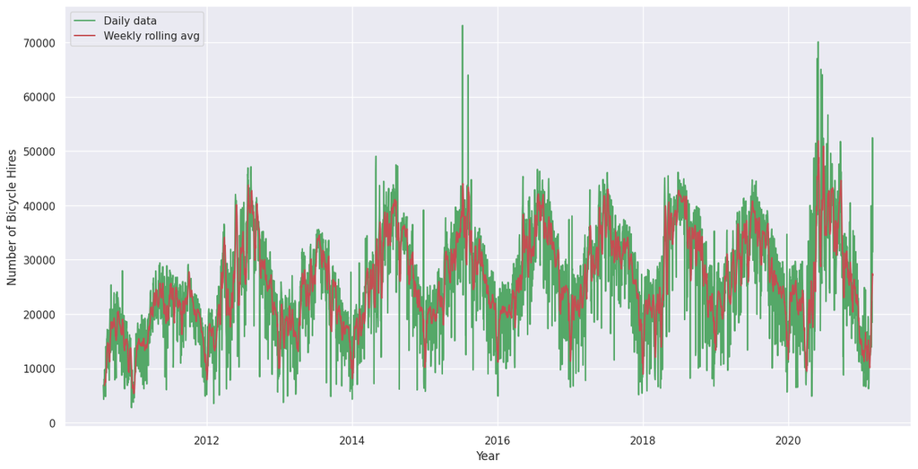

```python
sns.lineplot(x=DAY_COL, y=DAILY_HIRED_BICYCLES_COL, color='g',
             data=daily_hires_history_df, label='Daily data')

sns.lineplot(x=DAY_COL, y=f'rolling_7d_{DAILY_HIRED_BICYCLES_COL}', color='r',
             data=daily_hires_history_df, label='Weekly rolling avg')

plt.xlabel('Year')
plt.show()
```

На графике виден сезонный тренд в течении года -- больше спрос в середине, летом, чем например зимой. Довольно логично, в тёплый сезон чаще катаются на велосипедах

Я вижу аномально высокий спрос в 2015 и 2020.

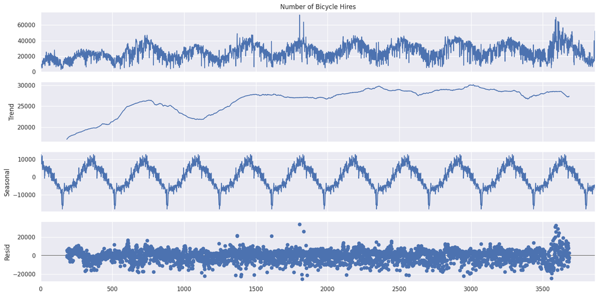

```python
decompose_result = seasonal_decompose(
    x=daily_hires_history_df[DAILY_HIRED_BICYCLES_COL],
    model='additive',
    period=365
)
ax = decompose_result.plot()
plt.show()
```

Как можно увидеть на графике, сезонность при аренде очень важный параметр. Она следует логике с пиками в тёплые сезоны.

Зелёная линия с первого графика и синяя со второго показывают что в неделе присутствует еще один тренд, вне зависимости от сезона

Глобальный тренд не сильно выделяется, если сравнивать с сезонным. Сразу после запуска тренд на аренду рос, но затем остановился в росте. Заметных изменений тренда в 2019 и 2020 во время пандемии не видно. Сходу не совсем понятно почему

Нужно изучить пики на графике и проанализировать причину.

```python
# Add columns
IS_HOLYDAY_COL = "Is UK holiday"
WEEKDAY_COL = "Day of week"
YEAR_COL = 'Year'
MONTH_COL = 'Month'
MONTH_NUM_COL = 'Month Number'
SEASON_COL = 'Season'
IS_WEEKEND_COL = 'Is Weekend'
SEASONS = ['Winter', 'Spring', 'Summer', 'Autumn']

SPECIFIC_YEAR_2019 = "General vs Specific"
SPECIFIC_YEAR_2020 = "General vs Specific"

SEASON_SHIFTED_COL = 'Season Shifted'
SEASON_HAS_CHANGED_COL = 'Season change'
SEASON_DATE_MIDDLE_COL = 'Season Middle Data'

PROPORTION_SUM_YEAR_COL = 'sum'

INTERCONNECTIONS_SUM_COL = 'Interconnections Total Income'

ELECTR_AMOUNT_COL = 'amount'
ELECTR_TYPE_COL = 'type'
```

```python
def month_no_to_season(month_no: int, seasons: List[str]= SEASONS) -> str:
    """
    Converts month num to a season name
    1 -> winter
    ...
    3 -> spring

    Args:
        month_no (int): month number
        seasons (List[str], optional): seasons names. Defaults to SEASONS.

    Returns:
        str: season name
    """

    keep_idx = month_no % 12 // 3
    return seasons[keep_idx]
```

```python
daily_hires_history_df = daily_hires_history_df.assign(
    **{
        WEEKDAY_COL: daily_hires_history_df[DAY_COL].dt.weekday,
        # holidays
        IS_HOLYDAY_COL: daily_hires_history_df[DAY_COL].isin(holidays_dates),
        YEAR_COL: daily_hires_history_df[DAY_COL].dt.year,
        # columns with month number and name
        MONTH_NUM_COL: daily_hires_history_df[DAY_COL].dt.month,
        MONTH_COL: daily_hires_history_df[DAY_COL].dt.strftime('%b'),
        SEASON_COL: daily_hires_history_df[DAY_COL].dt.month.map(month_no_to_season),
        IS_WEEKEND_COL: daily_hires_history_df[DAY_COL].dt.weekday > 4,
    }
)
```

```python
daily_hires_history_df.head()
```

|  | Day | Number of Bicycle Hires | rolling_7d_Number of Bicycle Hires | Day of week | Is UK holiday | Year | Month Number | Month | Season | Is Weekend |
| --- | --- | --- | --- | --- | --- | --- | --- | --- | --- | --- |
| 0 | 2010-07-30 | 6897 | NaN | 4 | False | 2010 | 7 | Jul | Summer | False |
| 1 | 2010-07-31 | 5564 | NaN | 5 | False | 2010 | 7 | Jul | Summer | True |
| 2 | 2010-08-01 | 4303 | NaN | 6 | False | 2010 | 8 | Aug | Summer | True |
| 3 | 2010-08-02 | 6642 | NaN | 0 | False | 2010 | 8 | Aug | Summer | False |
| 4 | 2010-08-03 | 7966 | NaN | 1 | False | 2010 | 8 | Aug | Summer | False |

```python
(
    daily_hires_history_df
    .sort_values(DAILY_HIRED_BICYCLES_COL, ascending=False)
    .head(10)
    [[DAY_COL, WEEKDAY_COL, IS_HOLYDAY_COL, MONTH_COL]]
)
```

|  | Day | Day of week | Is UK holiday | Month |
| --- | --- | --- | --- | --- |
| 1805 | 2015-07-09 | 3 | False | Jul |
| 3592 | 2020-05-30 | 5 | False | May |
| 3587 | 2020-05-25 | 0 | True | May |
| 3606 | 2020-06-13 | 5 | False | Jun |
| 3613 | 2020-06-20 | 5 | False | Jun |
| 1833 | 2015-08-06 | 3 | False | Aug |
| 3593 | 2020-05-31 | 6 | False | May |
| 3607 | 2020-06-14 | 6 | False | Jun |
| 3641 | 2020-07-18 | 5 | False | Jul |
| 3586 | 2020-05-24 | 6 | False | May |

Таблица показала два пика в 2015 году, а остальные даты в 2020 году приходятся на выходные в теплые месяцы. Кроме 25 мая 2020 года.

Возможно в 2015 в эти даты что-то происходило с транспортом или было какое-то городское мероприятие. Скорее всего это выброс

Полезно будет посмотреть на месячные агрегации

```python
# sum up all hires during the month
monthly_sum_agg_hires_df = (
    daily_hires_history_df
    .set_index(DAY_COL)
    .groupby([YEAR_COL, MONTH_COL])
    [DAILY_HIRED_BICYCLES_COL]
    .sum()
    .reset_index()
)

# mean hires for each month
monthly_mean_agg_hires_df = (
    monthly_sum_agg_hires_df
    .groupby(MONTH_COL)
    [DAILY_HIRED_BICYCLES_COL]
    .mean()
    .reset_index()
)

monthly_mean_agg_hires_df.sort_values(DAILY_HIRED_BICYCLES_COL, ascending=False, inplace=True)
```

```python
monthly_mean_agg_hires_df
```

|  | Month | Number of Bicycle Hires |
| --- | --- | --- |
| 5 | Jul | 995161.636364 |
| 6 | Jun | 981111.700000 |
| 1 | Aug | 960605.909091 |
| 8 | May | 943575.600000 |
| 11 | Sep | 909403.545455 |
| 10 | Oct | 834063.272727 |
| 0 | Apr | 761242.300000 |
| 7 | Mar | 677299.400000 |
| 9 | Nov | 674980.454545 |
| 4 | Jan | 565128.636364 |
| 3 | Feb | 555658.545455 |
| 2 | Dec | 527215.181818 |

```python
monthly_mean_agg = monthly_mean_agg_hires_df[DAILY_HIRED_BICYCLES_COL].values
most_active_month = monthly_mean_agg_hires_df[MONTH_COL].values[0]
lowest_active_month = monthly_mean_agg_hires_df[MONTH_COL].values[-1]
perc_diff = round(
    (monthly_mean_agg[0] / monthly_mean_agg[-1] - 1) * 100, 2
)

print(f"THe most active month is {most_active_month} has on average {perc_diff}% more bike hires than the lowest - {lowest_active_month}.")
```

```
THe most active month is Jul has on average 88.76% more bike hires than the lowest - Dec.
```

## 3.2 Seasons comparisson

```python
hires_for_2019 = daily_hires_history_df[daily_hires_history_df[YEAR_COL] == 2019]

hires_for_2019.loc[:, SPECIFIC_YEAR_2019] = 'Year 2019 hires data'
daily_hires_history_df.loc[:, SPECIFIC_YEAR_2019] = 'General hires data'

violin_plot_data = pd.concat([daily_hires_history_df, hires_for_2019], axis=0, ignore_index=True)
```

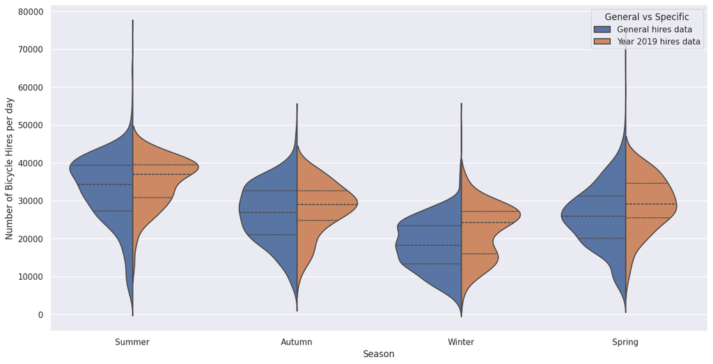

```python
sns.violinplot(
    data=violin_plot_data,
    x=SEASON_COL,
    y=DAILY_HIRED_BICYCLES_COL,
    linewidth=1.5,
    split=True,
    inner='quartile',
    hue=SPECIFIC_YEAR_2019
)
plt.ylabel("Number of Bicycle Hires per day")
plt.show()
```

Все так же наблюдается популярность в тёплые сезоны. Интересно что зимой есть бимодальное распределение популярности аренды - возможно было тепло

Отдельно нужно посмотреть на года в пандемию 2019 2020

```python
# finding boundaries for each season

seasonal_plot_slic_df = daily_hires_history_df[
    daily_hires_history_df[YEAR_COL]
    .isin([2019, 2020, 2021])
]

change_season = seasonal_plot_slic_df
change_season[SEASON_SHIFTED_COL] = (
    change_season[SEASON_COL]
    .shift(1)
    .fillna('')
)

change_season.loc[:, SEASON_HAS_CHANGED_COL] = (
    # shifted seasons by 1 day -> can compare neighbours and detect border between seasons
    1 * (change_season[SEASON_SHIFTED_COL] != change_season[SEASON_COL])
)
change_season.loc[:, SEASON_HAS_CHANGED_COL] = (
    change_season[SEASON_HAS_CHANGED_COL]
    .cumsum()
    # after cumsum every season would have a unique id
)

change_season = (
    change_season
    .reset_index()
    # and we can group by that id to get all rows for one season
    .groupby([SEASON_HAS_CHANGED_COL, SEASON_COL])
    [[DAY_COL]]
    .agg(['min', 'max'])
)

change_season.columns = [d[1] for d in change_season.columns]

change_season.loc[:, SEASON_DATE_MIDDLE_COL] = (
    change_season
    .apply(lambda x: x['min'] + (x['max'] - x['min']) / 2, axis=1)
)

change_season
```

| Season change | Season | min | max | Season Middle Data |
| --- | --- | --- | --- | --- |
| 1 | Winter | 2019-01-01 | 2019-02-28 | 2019-01-30 00:00:00 |
| 2 | Spring | 2019-03-01 | 2019-05-31 | 2019-04-15 12:00:00 |
| 3 | Summer | 2019-06-01 | 2019-08-31 | 2019-07-16 12:00:00 |
| 4 | Autumn | 2019-09-01 | 2019-11-30 | 2019-10-16 00:00:00 |
| 5 | Winter | 2019-12-01 | 2020-02-29 | 2020-01-15 00:00:00 |
| 6 | Spring | 2020-03-01 | 2020-05-31 | 2020-04-15 12:00:00 |
| 7 | Summer | 2020-06-01 | 2020-08-31 | 2020-07-16 12:00:00 |
| 8 | Autumn | 2020-09-01 | 2020-11-30 | 2020-10-16 00:00:00 |
| 9 | Winter | 2020-12-01 | 2021-02-28 | 2021-01-14 12:00:00 |

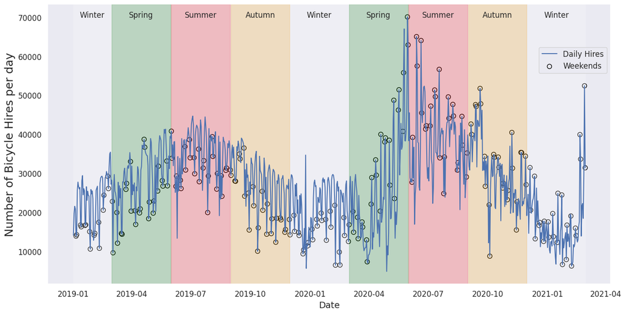

```python
fig, ax = plt.subplots()

ax.plot(
    seasonal_plot_slic_df[DAY_COL],
    seasonal_plot_slic_df[DAILY_HIRED_BICYCLES_COL],
    label='Daily Hires',
)

weekends_mask = seasonal_plot_slic_df[WEEKDAY_COL] > 4
weekends_df = seasonal_plot_slic_df[weekends_mask]

ax.scatter(
    weekends_df[DAY_COL],
    weekends_df[DAILY_HIRED_BICYCLES_COL],
    label='Weekends',
    facecolors='none',
    edgecolors='black',
    s=50,
)

for idx, row in change_season.reset_index().iterrows():
    if row[SEASON_COL] == SEASONS[0]:
        # winter
        color = 'white'
    elif row[SEASON_COL] == SEASONS[1]:
        # spring
        color = 'green'
    elif row[SEASON_COL] == SEASONS[2]:
        # summer
        color = 'red'
    elif row[SEASON_COL] == SEASONS[3]:
        # autumn
        color = 'orange'

    ax.axvspan(
        *mdates.datestr2num([str(row['min']), str(row['max'])]),
        color=color,
        alpha=0.2
    )

    plt.text(
        x=row[SEASON_DATE_MIDDLE_COL],
        y=70_000,
        s=row[SEASON_COL],
        size=12,
        rotation=0,
        ha='center'
    )

plt.xlabel('Date', fontsize=14)
plt.ylabel('Number of Bicycle Hires per day', fontsize=18)

plt.xticks(fontsize=12)
plt.yticks(fontsize=12)

plt.grid()
plt.legend(fontsize=12, loc='right', bbox_to_anchor=(1, 0.8))
plt.show()
```

Видно что есть рост популярность в локдаун 2020. Видимо транспорт ходил меньше или люди хотели изолироваться и не пользовались общественным транспортом

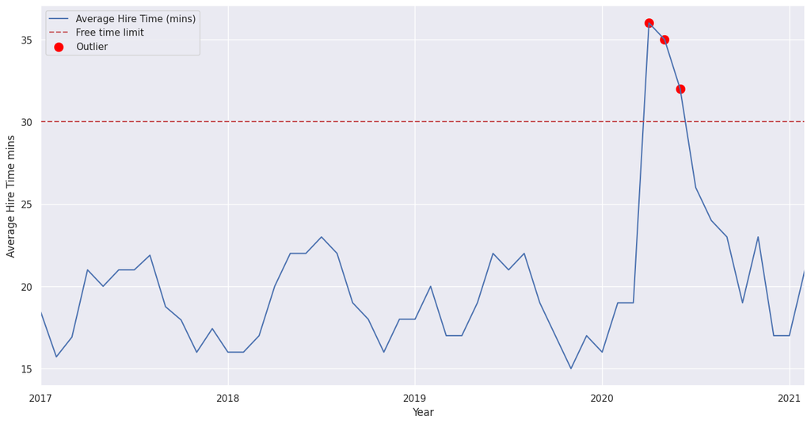

```python
monthly_avg_time_to_plot = monthly_avg_hire_time_df.tail(50).set_index(MONTH_COL)

monthly_avg_time_to_plot[AVG_HIRES_TIME_COL].plot()
plt.xlabel('Year')
plt.ylabel('Average Hire Time mins')
plt.axhline(y=30, color='r', linestyle='--', label='Free time limit')

high_avg_hire_time_mask = monthly_avg_time_to_plot[AVG_HIRES_TIME_COL] > 30
high_avg_hire_time_df = monthly_avg_time_to_plot[high_avg_hire_time_mask]

plt.scatter(high_avg_hire_time_df.index,
            high_avg_hire_time_df[AVG_HIRES_TIME_COL],
            label='Outlier',
            facecolors='red',
            edgecolors='red',
            s=100
            )

plt.legend()
plt.show()
```

```python
monthly_avg_hire_time_df[monthly_avg_hire_time_df[AVG_HIRES_TIME_COL] > 30]
```

|  | Month | Average Hire Time (mins) |
| --- | --- | --- |
| 117 | 2020-04-01 | 36.0 |
| 118 | 2020-05-01 | 35.0 |
| 119 | 2020-06-01 | 32.0 |

## 3.3 Intra-week seasonality

В добавление к годовой сезонности, нужно посмотреть на недельюную. Особенно на будние и выходные дни

```python
hires_for_2020 = daily_hires_history_df[daily_hires_history_df[YEAR_COL] == 2020]

hires_for_2020.loc[:, SPECIFIC_YEAR_2020] = 'Year 2020 hires data'
daily_hires_history_df.loc[:, SPECIFIC_YEAR_2020] = 'General hires data'

weekdays_violin_plot_data = pd.concat(
    [daily_hires_history_df, hires_for_2020]
)
```

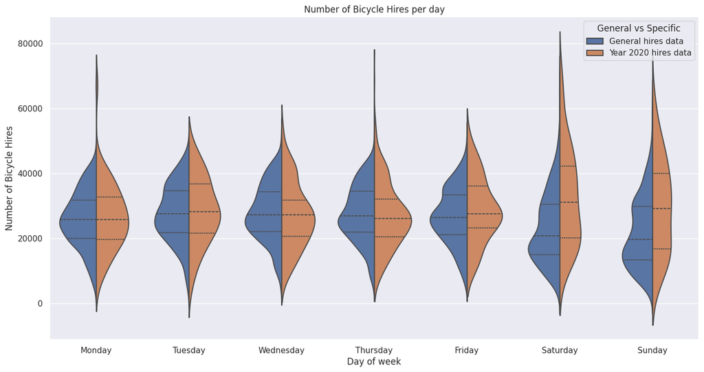

```python
sns.violinplot(
    data=weekdays_violin_plot_data,
    x=WEEKDAY_COL,
    y=DAILY_HIRED_BICYCLES_COL,
    linewidth=1.5,
    split=True,
    inner='quartile',
    hue=SPECIFIC_YEAR_2020,
)

plt.title('Number of Bicycle Hires per day')
days_of_week = [
    'Monday', 'Tuesday', 'Wednesday', 'Thursday',
    'Friday', 'Saturday', 'Sunday'
]

plt.xticks(ticks=range(len(days_of_week)), labels=days_of_week)
plt.show()
```

```python
# proportion between bicycle hires on weekends and weekdays
weekend_and_weekday_proportion_prep_df = (
    daily_hires_history_df
    [daily_hires_history_df.Year > 2015]
    .groupby([YEAR_COL, IS_WEEKEND_COL])
    [DAILY_HIRED_BICYCLES_COL]
    .mean()
)
```

```python
# calc sum for normalize values in one year
year_agg_mean_daily_hires_df = (
    weekend_and_weekday_proportion_prep_df
    .reset_index()
    .groupby(YEAR_COL)
    [DAILY_HIRED_BICYCLES_COL]
    .sum()
    .rename(PROPORTION_SUM_YEAR_COL)
)

# add sum
weekend_and_weekday_proportion_prep_df = pd.merge(
    weekend_and_weekday_proportion_prep_df.reset_index(),
    year_agg_mean_daily_hires_df.reset_index()
)

# calc proportion
weekend_and_weekday_proportion_prep_df.loc[:, DAILY_HIRED_BICYCLES_COL] = (
    weekend_and_weekday_proportion_prep_df[DAILY_HIRED_BICYCLES_COL]
    / weekend_and_weekday_proportion_prep_df[PROPORTION_SUM_YEAR_COL]
)
```

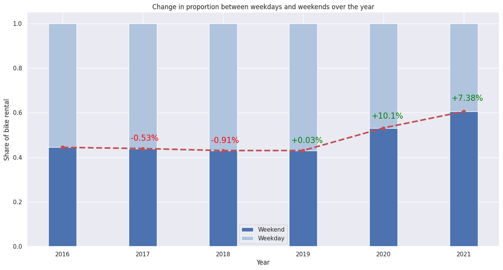

```python
fig, ax = plt.subplots()

weekend_data = (
    weekend_and_weekday_proportion_prep_df
    [weekend_and_weekday_proportion_prep_df[IS_WEEKEND_COL]]
    [DAILY_HIRED_BICYCLES_COL]
)

weekday_data = (
    weekend_and_weekday_proportion_prep_df
    [~weekend_and_weekday_proportion_prep_df[IS_WEEKEND_COL]]
    [DAILY_HIRED_BICYCLES_COL]
)

years_to_plot = (
    weekend_and_weekday_proportion_prep_df
    [YEAR_COL]
    .drop_duplicates()
)

ax.bar(years_to_plot, weekend_data, label='Weekend', width=0.35)
ax.bar(years_to_plot, weekday_data, label='Weekday', bottom=weekend_data, width=0.35, color='lightsteelblue')
plt.xlabel('Year')
plt.ylabel('Share of bike rental')
plt.legend()
plt.plot(years_to_plot, weekend_data, c='r', linewidth=3, marker='o', linestyle='dashed')

percentage_diffs = (weekend_data - weekend_data.shift(1))
for year, (cur_perc_diff, y_point) in enumerate(
    zip(percentage_diffs.values[1:], weekend_data[1:]),
    start=years_to_plot.values[1]
):
    cur_color = 'red' if cur_perc_diff < 0 else 'green'
    cur_perc_diff = round(cur_perc_diff * 100, 2)
    cur_perc_diff_str = str(cur_perc_diff) if cur_perc_diff < 0 else '+' + str(cur_perc_diff)
    cur_perc_diff = cur_perc_diff_str + '%'

    plt.text(year-0.15, y_point * 1.08, cur_perc_diff, fontsize=15, color=cur_color)


plt.title('Change in proportion between weekdays and weekends over the year')
plt.show()
```

Популярность аренды велосипеда на выходные сильно выросла с 2019 года - до 60% по сравнению с будними днями

## 3.4 Electrical Power high-level EDA

Для того чтобы понять есть ли зависимость данных аренды велосипедов и данных по электричеству, нужно провести еще EDA

```python
electrical_power_plot_df = electrical_power_df.copy()

# remove all negative values, so we can sum up to 100%
electrical_power_plot_df.loc[:, GEN_SOURCES_LIST + INTERCONNECTIONS_LIST] = (
    electrical_power_plot_df
    [GEN_SOURCES_LIST + INTERCONNECTIONS_LIST]
    .clip(0)
)
```

```python
# sum up all the sources to be a new total 100%
electrical_power_plot_df.loc[:, TOTAL_NET_SUPPLY_COL] = (
    electrical_power_plot_df
    [GEN_SOURCES_LIST + INTERCONNECTIONS_LIST]
    .sum(axis=1)
)

# count all interconnections as one for the plot
electrical_power_plot_df.loc[:, INTERCONNECTIONS_SUM_COL] = (
    electrical_power_plot_df
    [INTERCONNECTIONS_LIST]
    .sum(axis=1)
)

electrical_power_plot_df = (
    electrical_power_plot_df[
        [DAY_COL, INTERCONNECTIONS_SUM_COL, TOTAL_NET_SUPPLY_COL, *GEN_SOURCES_LIST]
    ]
)

power_to_plot_df = pd.melt(
    electrical_power_plot_df,
    id_vars=[DAY_COL, TOTAL_NET_SUPPLY_COL],
    value_vars=[INTERCONNECTIONS_SUM_COL, *GEN_SOURCES_LIST],
    var_name=ELECTR_TYPE_COL,
    value_name=ELECTR_AMOUNT_COL,
)
```

```python
# aggregate info about types by month and include total net supplies
power_info_grouped_by_month_df = (
    power_to_plot_df
    .set_index(DAY_COL)
    .groupby([ELECTR_TYPE_COL, pd.Grouper(freq='m')])
    [[ELECTR_AMOUNT_COL, TOTAL_NET_SUPPLY_COL]]
    .sum()
    .reset_index()
)
```

```python
# normalize amount of produced electricity by monthly sums
power_info_grouped_by_month_df.loc[:, ELECTR_AMOUNT_COL] = (
    power_info_grouped_by_month_df[ELECTR_AMOUNT_COL]
    / power_info_grouped_by_month_df[TOTAL_NET_SUPPLY_COL]
)
```

```python
# collect data for a plot
type_to_monthly_hist = (
    power_info_grouped_by_month_df
    .groupby(ELECTR_TYPE_COL)
    [ELECTR_AMOUNT_COL]
    .apply(list)
)
```

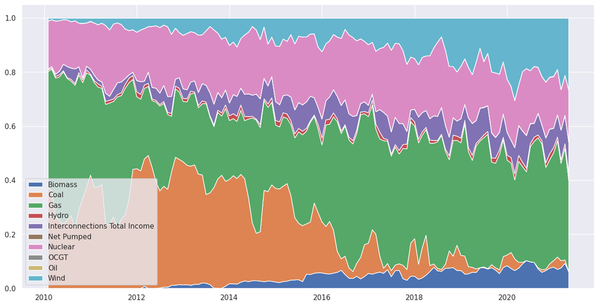

```python
dates_to_plot = power_info_grouped_by_month_df[DAY_COL].drop_duplicates()

plt.stackplot(
    dates_to_plot,
    labels=type_to_monthly_hist.index,
    *type_to_monthly_hist.values
)
plt.legend(loc="lower left")
plt.show()
```

C 2015 года уменьшилось потребление угля. При этом росла доля газа и ветряной энергии. Возможно эко политика перестраивала энергопотребление на более зеленый уровень. Это могло сказаться и на транспорте.

## 4 ML models

```python
import prophet
from sktime.forecasting.model_selection import ExpandingWindowSplitter
from sktime.performance_metrics.forecasting import MeanAbsoluteError, MeanAbsolutePercentageError
from statsmodels.tsa.stattools import adfuller
```

```
Importing plotly failed. Interactive plots will not work.
```

```python
ONE_FOLD_SIZE_IN_DAYS = 28 # 4 weeks
N_VAL_FOLDS = 5
```

```python
n_days_in_dataset = daily_hires_history_df[DAY_COL].shape[0]

initial_window_size = n_days_in_dataset - ONE_FOLD_SIZE_IN_DAYS * (N_VAL_FOLDS + 1)

splitter = ExpandingWindowSplitter(
    fh=ONE_FOLD_SIZE_IN_DAYS,
    initial_window=initial_window_size,
    step_length=ONE_FOLD_SIZE_IN_DAYS,
)
```

```python
# split the data into 6 folds
all_splits = list(splitter.split(daily_hires_history_df[DAY_COL]))
train_cv_splits = all_splits[:-1]
test_split = all_splits[-1]
```

```python
# take the middle split
indices_to_analyze = train_cv_splits[-3][0]
train_df_to_analyze = daily_hires_history_df.loc[indices_to_analyze]
```

### Dickey-Fuller test for time series stationarity

```python
def get_af_pval(inp_seq) -> float:
    p_value = adfuller(inp_seq)[1]
    return p_value

df_pval = get_af_pval(train_df_to_analyze[DAILY_HIRED_BICYCLES_COL])
print(f"Dickey-Fuller test p-value: {df_pval}")
```

```
Dickey-Fuller test p-value: 0.0017751730539649914
```

### baseline

```python
## Additional columns, created in the process
HOLIDAY_COL = 'holiday'
DS_COL = 'ds'
TARGET_COL = 'y'
PREDS_PROPHET_COL = 'yhat'

PROPHET_WEEKLY_COL = 'weekly'
```

```python
uk_holidays_df_to_prophet = uk_holidays_df.rename({HOLIDAYS_DATE_COL: DS_COL}, axis=1)
uk_holidays_df_to_prophet[HOLIDAY_COL] = HOLIDAY_COL
```

```python
sample_train_df = (
    daily_hires_history_df.iloc[indices_to_analyze, :]
    .rename({DAY_COL: DS_COL, DAILY_HIRED_BICYCLES_COL: TARGET_COL}, axis=1)
    [[DS_COL, TARGET_COL]]
)

val_start_idx = indices_to_analyze[-1] + 1
val_end_idx = val_start_idx + ONE_FOLD_SIZE_IN_DAYS

sample_val_df = (
    daily_hires_history_df.iloc[val_start_idx: val_end_idx, :]
    .rename({DAY_COL: DS_COL, DAILY_HIRED_BICYCLES_COL: TARGET_COL}, axis=1)
    [[DS_COL, TARGET_COL]]
)
```

```python
def train_and_predict_prophet_model(
        model: prophet.Prophet,
        train_df: pd.DataFrame,
        valid_df: pd.DataFrame
):
    model.fit(train_df)
    preds = model.predict(model.make_future_dataframe(ONE_FOLD_SIZE_IN_DAYS))
    return preds
```

```python
base_model = prophet.Prophet(
    holidays=uk_holidays_df_to_prophet,
    daily_seasonality=False,
)

sample_preds_prophet = train_and_predict_prophet_model(
    base_model,
    sample_train_df,
    sample_val_df
)
```

```
03:35:43 - cmdstanpy - INFO - Chain [1] start processing
03:35:44 - cmdstanpy - INFO - Chain [1] done processing
```

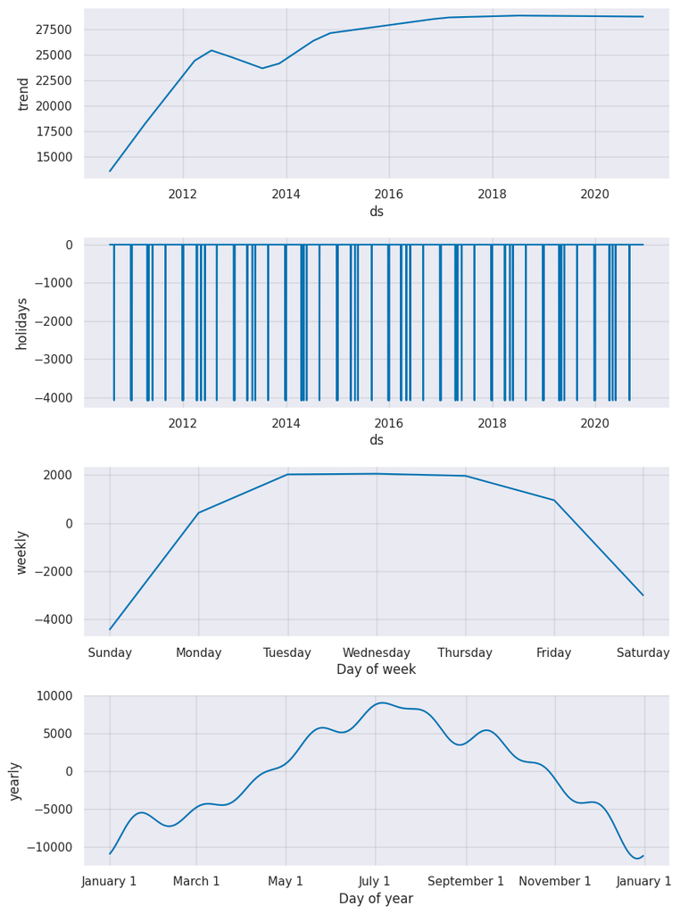

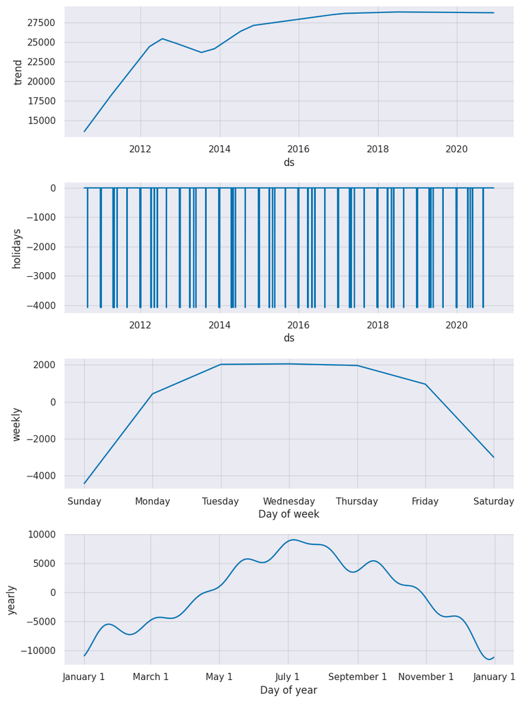

```python
base_model.plot_components(sample_preds_prophet)
```

```python
def plot_ts_preds_and_gts(
        train_series: pd.Series,
        val_series: pd.Series,
        preds_series: pd.Series
):
    plt.plot(train_series, label='Bike hires history')
    plt.plot(preds_series, color='r', label='Predictions')
    plt.plot(val_series, label='GT val', color='green')
    plt.ylabel('Number of hired bikes')
    plt.xlabel('Date')
    plt.legend()
```

```python
# plot only small amount of training data 365 / 4

train_to_plot = sample_train_df.set_index(DS_COL).tail(365//4)[TARGET_COL]
val_to_plot = sample_val_df.set_index(DS_COL)[TARGET_COL]

preds_to_plot = sample_preds_prophet.set_index(DS_COL).tail(ONE_FOLD_SIZE_IN_DAYS)[PREDS_PROPHET_COL]
```

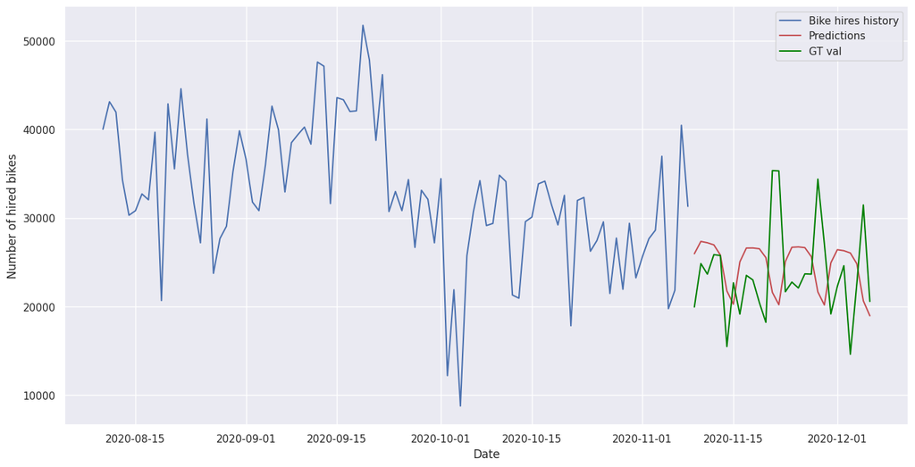

```python
plot_ts_preds_and_gts(train_series=train_to_plot,
                      val_series=val_to_plot,
                      preds_series=preds_to_plot)
```

Meh. Видно что модель не отслеживает внутреннюю сезонность

```python
train_to_plot.tail(2)
```

```
ds
2020-11-07    40467
2020-11-08    31315
Name: y, dtype: int64
```

```python
preds_to_plot.head(2)
```

```
ds
2020-11-09    25966.854943
2020-11-10    27357.717879
Name: yhat, dtype: float64
```

День не потерян

```python
def calc_metrics(gt, pred):
    mae_metric = MeanAbsoluteError()
    smape_metric = MeanAbsolutePercentageError(symmetric=True)

    mae_val = mae_metric(gt, pred)
    smape_val = smape_metric(gt, pred)
    return {'MAE': mae_val, 'SMAPE': smape_val}
```

```python
calc_metrics(val_to_plot, preds_to_plot)
```

```
{'MAE': 5392.165053770165, 'SMAPE': 0.22269428884152395}
```

Попробуем обучить модель только на последних данных

```
03:35:53 - cmdstanpy - INFO - Chain [1] start processing
03:35:53 - cmdstanpy - INFO - Chain [1] done processing
```

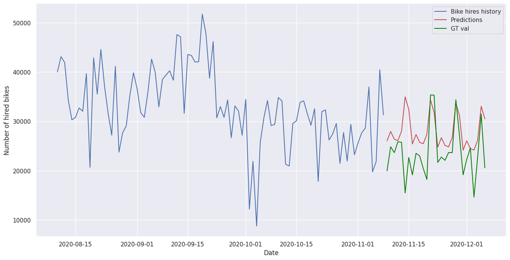

```python
base_model_short = prophet.Prophet(
    holidays=uk_holidays_df_to_prophet,
    daily_seasonality=False,
)

sample_train_df_short = sample_train_df[sample_train_df[DS_COL] > '2020-03-01']

sample_preds_prophet_short = train_and_predict_prophet_model(
    base_model_short,
    sample_train_df_short,
    sample_val_df
)

preds_to_plot_short = (
    sample_preds_prophet_short
    .set_index(DS_COL)
    .tail(ONE_FOLD_SIZE_IN_DAYS)
    [PREDS_PROPHET_COL]
)

plot_ts_preds_and_gts(train_to_plot, val_to_plot, preds_to_plot_short)
```

```python
calc_metrics(val_to_plot, preds_to_plot_short)
```

```
{'MAE': 4559.702550222546, 'SMAPE': 0.1865528328892398}
```

Лучше, и по графикам и по метрикам. Но мы используем не все данные из датасета. Попробую скомбинировать модели

TBD:

1 add models combination

2 add energy data